# İsim: Muhammet Fatih

# Soyisim: ANAÇ

# Numara: 121521057

# Gerekli Paketlerin Yüklenmesi

```python
import pandas as pd
import numpy as np
import statsmodels.api as sm
from sklearn.linear_model import LinearRegression
from sklearn.model_selection import train_test_split
import scipy.stats as stats
import matplotlib.pyplot as mpl
from sklearn.metrics import mean_squared_error, r2_score
import seaborn as sb
from sklearn.preprocessing import scale
from sklearn.decomposition import PCA
from sklearn import model_selection
from sklearn.model_selection import KFold
from sklearn.cross_decomposition import PLSRegression
from sklearn.model_selection import cross_val_predict
from sklearn.linear_model import Ridge
from sklearn.linear_model import Lasso
from sklearn.linear_model import LassoCV
from sklearn.neighbors import KNeighborsRegressor
from sklearn.model_selection import GridSearchCV
from sklearn.svm import SVR
from sklearn.preprocessing import StandardScaler
from sklearn.neural_network import MLPRegressor
from sklearn.tree import DecisionTreeRegressor
from sklearn.ensemble import BaggingRegressor
from sklearn.ensemble import RandomForestRegressor
from sklearn.ensemble import GradientBoostingRegressor
import xgboost as xgb
from xgboost import XGBRegressor
```

```python
import warnings
warnings.filterwarnings('ignore')
```

```python
cd C:\Users\m.fatih\OneDrive\Masaüstü\İstatistiksel Yazılımlar 2 Vize Ödevi
```

```
C:\Users\m.fatih\OneDrive\Masaüstü\İstatistiksel Yazılımlar 2 Vize Ödevi
```

```python
veri=pd.read_csv("concrete_data.csv")
```

# Verinin Tanıtılması

```python
veri.head()
```

|  | Cement | Blast Furnace Slag | Fly Ash | Water | Superplasticizer | Coarse Aggregate | Fine Aggregate | Age | Strength |
| --- | --- | --- | --- | --- | --- | --- | --- | --- | --- |
| 0 | 540.0 | 0.0 | 0.0 | 162.0 | 2.5 | 1040.0 | 676.0 | 28 | 79.99 |
| 1 | 540.0 | 0.0 | 0.0 | 162.0 | 2.5 | 1055.0 | 676.0 | 28 | 61.89 |
| 2 | 332.5 | 142.5 | 0.0 | 228.0 | 0.0 | 932.0 | 594.0 | 270 | 40.27 |
| 3 | 332.5 | 142.5 | 0.0 | 228.0 | 0.0 | 932.0 | 594.0 | 365 | 41.05 |
| 4 | 198.6 | 132.4 | 0.0 | 192.0 | 0.0 | 978.4 | 825.5 | 360 | 44.30 |

### Verideki 'Cement' değişkeni çimento miktarını, 'Blast Furnace Slag' değişkeni yüksek fırın cürufunu, 'Fly Ash' değişkeni uçucu kül miktarını, 'Water' değişkeni su miktarını, 'Coarse Aggregate' değişkeni iri agregalar kum miktarını, 'Fine Aggregate' değişkeni ince agregalar kum miktarını, 'Age' değişkeni yaş değerini gösteriyor. 'Strength' değişkeni ise betonun dayanıklılığını gösteriyor.

### 'Strength' değişkeni bağımlı değişken, diğer değişkenler bağımsız değişken.

# Verinin Eğitim ve Test Olarak Ayrılması

```python
np.random.seed(123)
y= veri["Strength"]
X= veri.drop("Strength", axis=1)
X_egitim, X_test, y_egitim, y_test = train_test_split(X,y, test_size=0.3, random_state= 1)
```

### Veriyi %30 test verisi %70 eğitim verisi olarak ayırdım.

# Çoklu Doğrusal Regresyon (OLS)

# Modelin Kurulması

```python
model=LinearRegression().fit(X_egitim, y_egitim)
print(" Intercept:",model.intercept_,"\n","Coef: ", model.coef_)
```

```
 Intercept: -13.356302642849755
 Coef:  [ 0.12198785  0.10524275  0.08729552 -0.15478128  0.33176191  0.01258243
  0.01436308  0.11555199]
```

# Eğitim Verisi Üzerinden Tahmin (In-Sample Prediction)

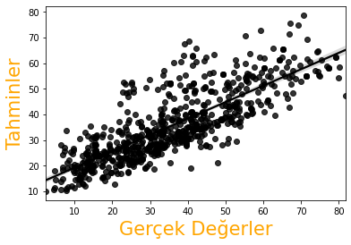

```python
yhat_OLS = model.predict(X_egitim)
fig, ax = mpl.subplots()
sb.regplot(y_egitim, yhat_OLS,color="black")
ax.set_ylabel("Tahminler", fontsize=21, color="orange")
ax.set_xlabel("Gerçek Değerler", fontsize=21, color="orange")
```

### Grafik incelendiğinde doğrusal bir ilişki görülüyor. Bu doğrusal ilişki, gerçek y değerlerini model üzerinden tahmin edebildiğimizi gösteriyor. Ne kadar iyi tahmin aldığımızı R2 ve mse değerleri üzerinden görebiliriz:

```python
print(" R2: ", r2_score(y_egitim, yhat_OLS), "\n","MSE: ",mean_squared_error(y_egitim, yhat_OLS))
```

```
 R2:  0.6411898137954829
 MSE:  102.53194750160517
```

### R2 değeri 0.64 olarak hesaplanmıştır. Bağımlı değişkendeki toplam değişimin %64'ü bağımsız değişkenler tarafından açıklanmaktadır. MSE değerine göre, tahmin edilen değerler gerçek değerlerden uzaktır.

### R2=0.64 değeri çok da iyi bir değer değildir. 1'e daha yakın olmasını bekliyoruz. MSE değerinin de daha düşük olmasını bekliyoruz.

# Test Verisi Üzerinden Tahmin (Out-Of-Sample Prediction)

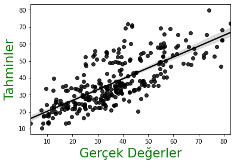

```python
y_tahmin_OLS = model.predict(X_test)
fig, ax = mpl.subplots()
sb.regplot(y_test, y_tahmin_OLS, color="black")
ax.set_ylabel("Tahminler", fontsize=21, color="green")
ax.set_xlabel("Gerçek Değerler", fontsize=21, color="green")
```

### Grafik incelendiğinde doğrusal bir ilişki görülüyor ama değerlerin arasında fazla mesafe olduğu görülüyor. Bu durum, gerçek y değerlerini o kadar da iyi tahmin edemediğimizi gösteriyor.

```python
print(" R2: ", r2_score(y_test, y_tahmin_OLS), "\n","MSE: ", mean_squared_error(y_test, y_tahmin_OLS))
```

```
 R2:  0.5414805238935221
 MSE:  120.18125557536798
```

### R2 değerinden; bağımlı değişkendeki toplam değişimin %54'ünün bağımsız değişkenler tarafından açıklandığı görülüyor.

### MSE değerine göre, tahmin edilen değerler, gerçek değerlerden uzaktır.

### Modelin eğitim verisi performansı ve test verisi performansı incelendiğinde, iyi tahminler elde edebilmemiz için OLS modelin yetersiz kaldığı görülüyor. R2 değerinin 1'e daha yakın, MSE değerinin daha düşük olması gerekiyor.

# PCR

## Cross Validation

```python
cv= KFold(n_splits= 10, shuffle=True, random_state= 1)
X_egitim_scaled=PCA().fit_transform(scale(X_egitim))

model = LinearRegression()
scr = []

for i in np.arange(1,9):
    scr_i= -1*model_selection.cross_val_score(model, X_egitim_scaled[:,:i], y_egitim, cv=cv,
                                              scoring='neg_mean_squared_error').mean()
    scr.append(scr_i)
```

```python
scr=np.array(scr)
n_degisken=np.arange(1,9)
n_degisken=np.array(n_degisken)
tablo=pd.concat([pd.DataFrame(n_degisken),pd.DataFrame(scr)], axis=1)
tablo.columns=("Değişken Sayısı","Score")
tablo
```

|  | Değişken Sayısı | Score |
| --- | --- | --- |
| 0 | 1 | 285.334993 |
| 1 | 2 | 255.996635 |
| 2 | 3 | 191.527150 |
| 3 | 4 | 191.147078 |
| 4 | 5 | 165.555744 |
| 5 | 6 | 119.342146 |
| 6 | 7 | 110.423676 |
| 7 | 8 | 105.986205 |

### Score sonuçları incelendiğinde ilk ciddi düşüşün 3 değişkenin kullanıldığı durumda olduğu görülüyor. 6 değişkenin kullanıldığı durumda da ikinci ciddi düşüş görülüyor.

### Bu durumu grafik üzerinden daha detaylı görelim:

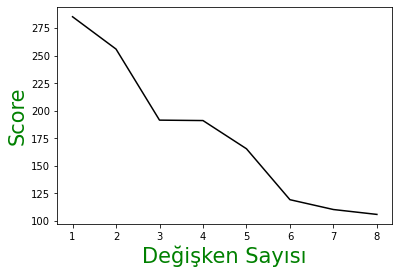

```python
fig, ax = mpl.subplots()
mpl.plot(n_degisken,scr,color="black")
ax.set_ylabel("Score", fontsize=21, color="green")
ax.set_xlabel("Değişken Sayısı", fontsize=21, color="green")
```

### Grafik üzerinden de aynı sonuçlar görülüyor. Bu durumda hem 3 değişken kullanarak hem de 6 değişken kullanarak 2 ayrı model kurup iki modelin performansı karşılaştırılabilir.

# 3 Değişken Üzerinden Modelin Kurulması

```python
pca_model1=LinearRegression().fit(X_egitim_scaled[:,:3], y_egitim)
```

# Eğitim Verisi Üzerinden Tahmin (In-Sample Prediction)

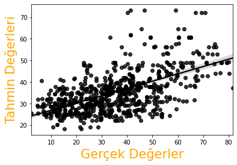

```python
yhat_2_PCR=pca_model1.predict(X_egitim_scaled[:,:3])
fig, ax = mpl.subplots()
sb.regplot(y_egitim, yhat_2_PCR, color="black")
ax.set_ylabel("Tahmin Değerleri", fontsize=21, color="orange")
ax.set_xlabel("Gerçek Değerler", fontsize=21, color="orange")
```

### 3 değişken kullanılarak kurulan modelin performansı grafik üzerinden incelendiğinde, değerlerin çok dağınık olduğu; değerlerin, çizilen doğru üzerinde yoğunlaşmadığı görülüyor.

### Grafik incelendiğinde, iyi tahminler elde edebilmek için 3 değişkenin yeterli olmadığı görülüyor.

```python
print(" R2 Değeri: ",r2_score(y_egitim, yhat_2_PCR),"\n","MSE Değeri: ",mean_squared_error(y_egitim, yhat_2_PCR))
```

```
 R2 Değeri:  0.3376134201893769
 MSE Değeri:  189.28054062601083
```

### R2 değeri; bağımlı değişkendeki toplam değişimin %33'ünün, PCR ile elde edilen scorelar tarafından açıklandığını gösteriyor.

### MSE değerine göre, tahmin edilen değerler gerçek değerlerden uzaktır.

### Bu sonuçlar grafik sonuçlarını doğruluyor. İyi tahminler elde edebilmemiz için 3 değişken yeterli değildir.